# Chemistry

Research Cluster 7

Cluster 7 brings together research on how compounds are made, how their atoms are arranged, and how that arrangement shapes their behaviour. Several communities focus on metal complexes, in which groups called ligands bind to a metal centre. Some examine how these complexes are built or how they come apart. Others ask how changes to the ligands affect the reactions a complex can take part in. X-ray methods, spectroscopy, and computer calculations recur across these communities as ways to determine molecular structure and explain chemical behaviour.

The study of reactivity connects this work to questions about how to make particular products. Some communities examine how catalysts help join molecules into polymer chains or form bonds between carbon and nitrogen. Others look at how compounds gain or lose electrons, including work on indium and bismuth that extends the cluster’s scope beyond transition metals. The interest in structure also extends to arrangements involving many molecules, as in studies of hydrogen-bond networks in solids and salts that can remain liquid near room temperature.

Several communities give this chemistry a materials or biomedical application. Research on atomic layer deposition evaluates metal compounds as starting materials for growing thin films. The biomedical communities ask different questions about what compounds do in living systems, from their potential activity against tuberculosis to the role of cholinesterase enzymes in Alzheimer’s research and the toxicity of compounds following exposure.

Renewable energy design forms a distinct engineering strand within the cluster. Its focus is on how generation, storage, and control can be combined to meet goals such as lower cost or to support an application such as desalination. The unit of design here is an operating system, while much of the chemistry research asks how the properties of individual compounds can be understood and put to use.

Three forms of evidence below show what the keyword communities are about and how they relate to one another.

**Interactive keyword network.** Each point represents a keyword, and a line connects two keywords that appear together in one or more publications. The full network shows how keyword communities relate to one another. Select a community from the dropdown to see which terms group together and which connect to terms in other communities. Connections within a community show which subjects, methods, or concepts appear together. Connections across communities show where their vocabularies overlap.

**Community word clouds.** Each cloud shows the vocabulary of one community. Larger words have higher within-community PageRank. This measure reflects both the strength of a keyword’s connections and how well connected its neighbours are. Larger words therefore show which terms are most prominent in the community’s pattern of connections. Smaller words can give those terms context by identifying particular subjects, settings, or methods.

**Affiliated publications.** Each publication has a set of membership values, one for each community. A value of 1 means that all of the publication’s keyword-based membership is assigned to that community. When membership is distributed across communities, the values show how that affiliation is shared. For example, values of 0.7 and 0.3 indicate that the publication’s keywords align more strongly with the first community while also connecting it to the second. The publication lists show how the themes visible in the keyword network are represented in the institution’s research.

[interactive chart not shown]

## Community 1: Structure and reactivity of metal complexes

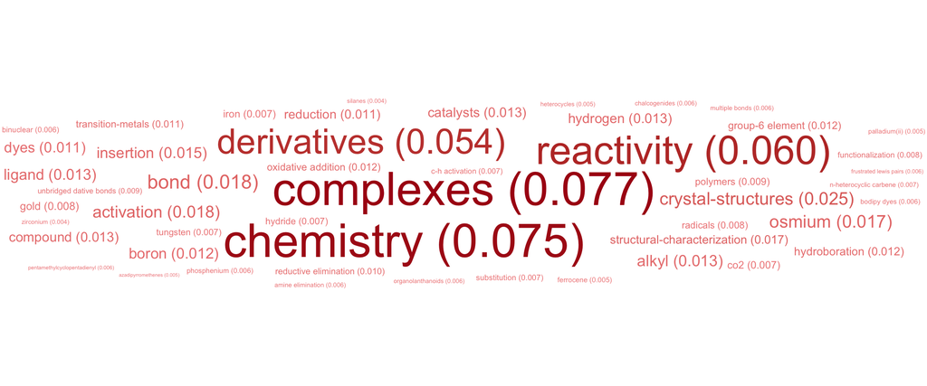

Community 1 of Cluster 7 centres on how metal complexes are put together and how they react. “Complexes” (0.077), “chemistry” (0.075), “reactivity” (0.060), and “derivatives” (0.054) have the highest within-community PageRank. The structural terms give this focus more detail. “Crystal-structures,” “structural-characterization,” and “ligand” point to questions about how atoms and ligands are arranged around metals such as osmium and tungsten. “Activation,” “insertion,” “oxidative addition,” and “reductive elimination” point to how bonds break, form, or rearrange during reactions. Catalysis is one part of that broader inquiry, with hydroboration among the transformations under study. The table also points to work on boron dyes. For comparisons with the communities that follow, the defining feature here is the attention given to both the structure of metal complexes and the changes they undergo.

## Community 2: Crystal and molecular structure

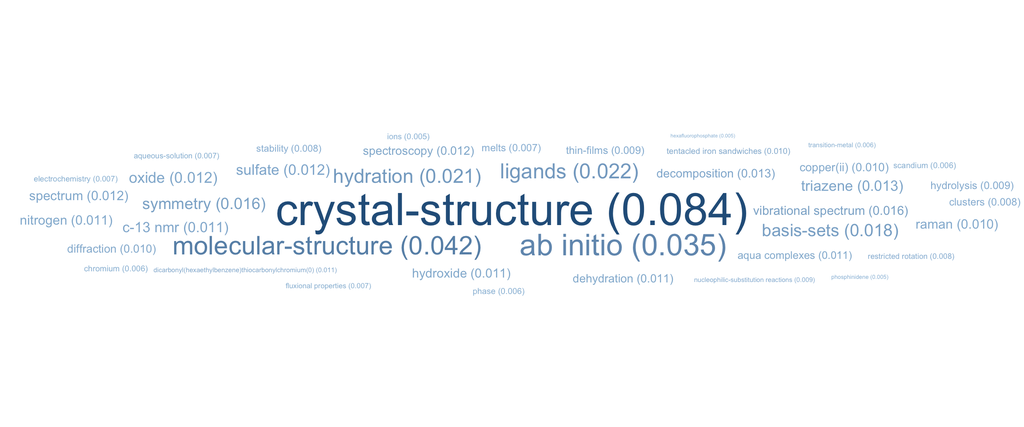

Community 2 of Cluster 7 centres on how researchers determine and explain the structure of crystals and molecules. “Crystal-structure” has the highest within-community PageRank (0.084), followed by “molecular-structure” (0.042) and “ab initio” (0.035). Diffraction, Raman spectroscopy, and carbon-13 NMR point to different kinds of experimental evidence, while “ab initio” and “basis-sets” point to calculations used to model molecular structures and interpret their properties. Keywords such as “symmetry” and “vibrational spectrum” show the kinds of features this work seeks to explain. “Restricted rotation” and “fluxional properties” add a question about how molecular arrangements change, while “hydration,” “dehydration,” and “aqua complexes” point to an interest in how compounds incorporate, bind, or lose water.

Ligands and metal complexes connect this community to Community 1. Both examine how atoms are arranged around metal centres, with examples here involving chromium, copper, and iron. Community 1 connects those arrangements to reactions such as insertion and oxidative addition. Community 2 gives more weight to the methods used to establish molecular structure and to questions about how that structure varies with molecular motion or interaction with water.

## Community 3: Renewable energy system design and optimization

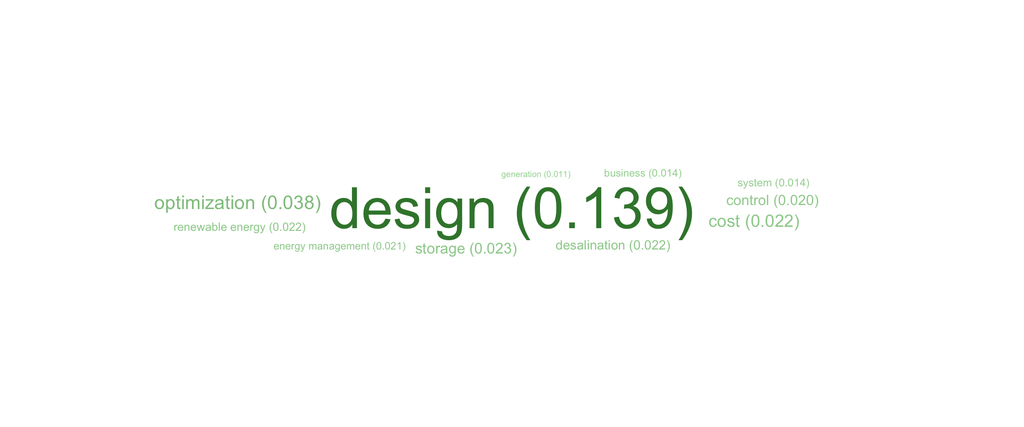

Community 3 of Cluster 7 centres on how renewable energy systems are designed and operated. “Design” has the highest within-community PageRank (0.139), followed by “optimization” (0.038). “Generation,” “storage,” “energy management,” and “control” point to two related questions: which components to combine, and how to coordinate them once the system is operating. “Cost” identifies a criterion for evaluating design choices, while “desalination” gives the work a specific application.

The distinction from Communities 1 and 2 is the scale of the research. Community 1 examines the structure and reactivity of metal complexes, and Community 2 examines how researchers determine crystal and molecular structure. Community 3 shifts the focus to how technologies are configured and managed to meet an operating goal, giving the cluster a distinct engineering strand.

## Community 4: Antimicrobial compound discovery and characterization

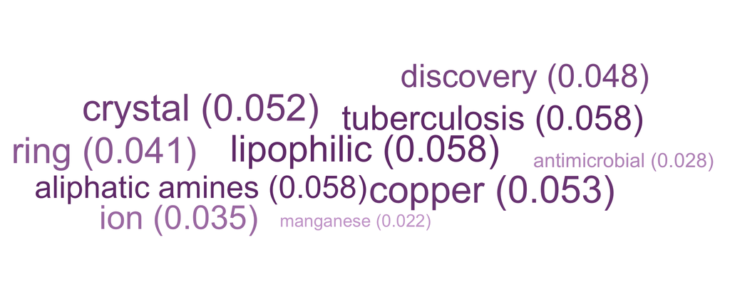

This community brings compound discovery and characterization into a biomedical setting, with tuberculosis as the named application. “Aliphatic amines” identifies a class of compounds, while “lipophilic” points to an interest in how readily compounds associate with fats or other nonpolar environments. “Discovery” and “antimicrobial” give those terms a biological context. “Copper,” “manganese,” and “crystal” also point to work on metal compounds and their structures, though the keyword table leaves open how closely that work relates to the tuberculosis research.

The metal and crystal terms connect this community to Communities 1 and 2, which examine the structure and reactivity of metal complexes and the methods used to determine molecular structure. What stands out here is the question of what compounds might do in a biological setting, particularly their potential antimicrobial activity.

## Community 5: Adduct formation and dissociation

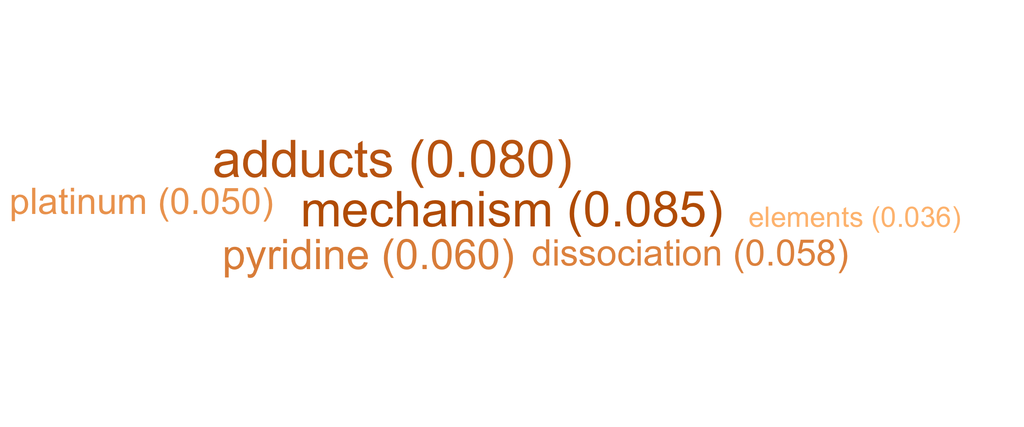

This community focuses on how chemical species bind to form adducts and how those adducts dissociate. “Mechanism” (0.085) and “adducts” (0.080) have the highest within-community PageRank, while “pyridine” (0.060) and “platinum” (0.050) suggest a focus on metal–ligand interactions. This connects the community to Community 1’s work on the structure and reactivity of metal complexes and to Community 2’s interest in how ligands are arranged around metal centres. The emphasis here is on the steps by which those associations form or come apart. The keyword table leaves open whether the pyridine and platinum terms refer to the same set of compounds.

## Community 6: Phosphorus chemistry, Lewis acidity, and metal catalysis

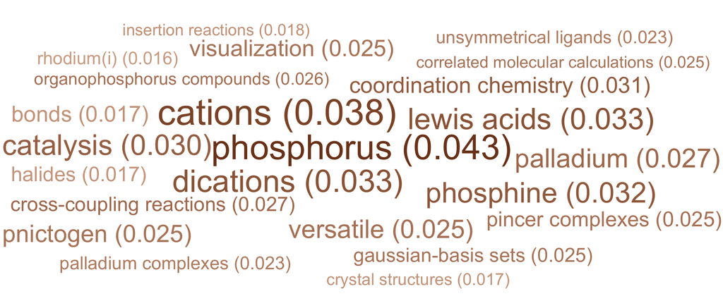

This community brings together research on phosphorus compounds, coordination chemistry, and catalysis. “Phosphine,” “pincer complexes,” and “unsymmetrical ligands” point to questions about how ligands bind to metals and influence their reactivity. “Palladium” and “cross-coupling reactions” give that work a specific catalytic setting. Alongside it, “cations,” “dications,” and “Lewis acids” point to research on bonding and electron-pair acceptance in positively charged species.

The closest overlap is with Community 1, which also examines the structure and reactivity of metal complexes. Here, the focus narrows to phosphorus compounds and the role of ligands in reactions such as palladium cross-coupling. Crystal structures and molecular calculations connect the community to Community 2’s work on determining and interpreting structure. The emphasis on binding also links it to the adduct community, where the question is how associations form and dissociate.

## Community 7: Transition-metal coordination chemistry

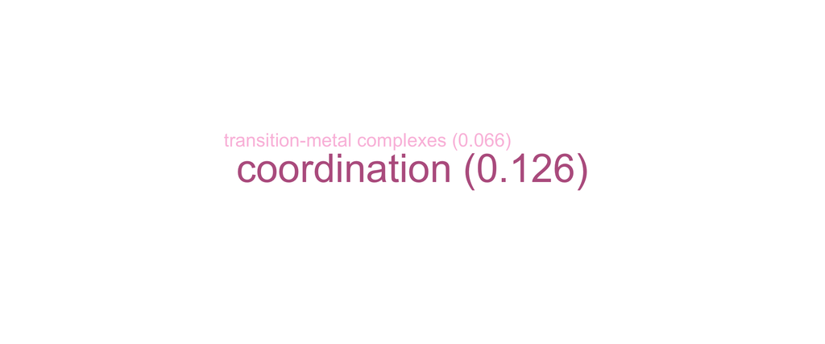

This community points to the study of how ligands bind to transition-metal centres. “Coordination” (0.126) has nearly twice the within-community PageRank of “transition-metal complexes” (0.066). The closest connection is to Community 1, where coordination provides a basis for studying both the structure of metal complexes and how they react. The two keywords here support a broad coordination chemistry label and leave open which metals, ligands, or reactions the research emphasizes.

## Community 8: Transition-metal complexes, catalysis, and polymerization

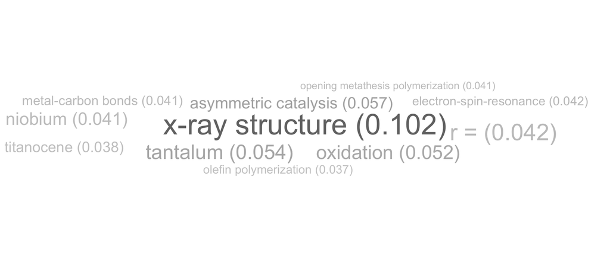

This community in Cluster 7 examines the structure and reactivity of transition-metal complexes. “X-ray structure” has the highest within-community PageRank (0.102), followed by “asymmetric catalysis” (0.057), “tantalum” (0.054), and “oxidation” (0.052). “Metal-carbon bonds,” “niobium,” and “titanocene” give the community an organometallic focus. The catalytic terms point to two kinds of work. Asymmetric catalysis concerns reactions that favour one mirror-image form of a product, while olefin polymerization and ring-opening metathesis polymerization concern how small molecules are joined into polymer chains.

The combination of structural characterization and reactivity connects this community to Community 1’s work on metal complexes. X-ray structure also connects it to Community 2’s interest in how researchers determine molecular arrangements. Its catalytic focus differs from that of the phosphorus and Lewis acidity community, where palladium cross-coupling is the named application. Here, the keywords give more attention to controlling the spatial arrangement of reaction products and to building polymers.

## Community 9: Ionic liquids and chloride salt chemistry

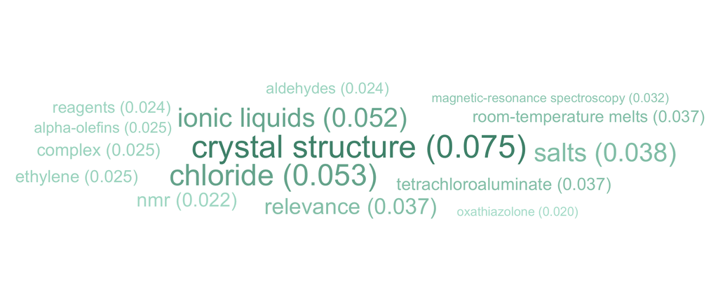

This community focuses on the structure and chemistry of ionic liquids, with chloride salts as a point of emphasis. “Crystal structure” has the highest within-community PageRank (0.075), followed by “chloride” (0.053) and “ionic liquids” (0.052). “Salts,” “tetrachloroaluminate,” and “room-temperature melts” give the community a more specific focus on the composition and structure of salts that can be liquid near room temperature. “Magnetic-resonance spectroscopy” and “NMR” point to another way researchers characterize the compounds under study.

The emphasis on structural characterization connects this community to Community 2’s work on crystal and molecular structure. The chemistry it foregrounds is different from that of the preceding community, where X-ray structure appears alongside transition-metal complexes, asymmetric catalysis, and polymerization. Here, the most distinctive terms concern salts and ionic liquids. “Ethylene,” “alpha-olefins,” and “aldehydes” also appear, though the keyword table leaves open how those reagents relate to the ionic liquids work.

## Community 10: Amination and catalytic synthesis under mild conditions

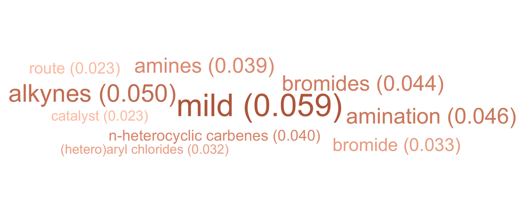

This community focuses on synthetic routes for forming bonds under mild conditions. “Amination,” “amines,” “bromides,” and “(hetero)aryl chlorides” point to research on forming carbon–nitrogen bonds using amines and halide substrates. “Catalyst” and “N-heterocyclic carbenes” give the grouping a catalytic dimension, while the prominence of “alkynes” suggests a related interest in transformations involving carbon–carbon triple bonds. The keyword table leaves open whether the alkyne and amination terms describe the same reactions.

The closest connection is to the phosphorus and Lewis acidity community, where palladium cross-coupling also brings ligand chemistry into synthetic reactions. Community 1 provides a broader parallel through its emphasis on how compounds react and how their bonds change. Here, the focus is on developing routes to particular products and on the conditions under which those routes work.

## Community 11: Molecular recognition and hydrogen bonding in solids

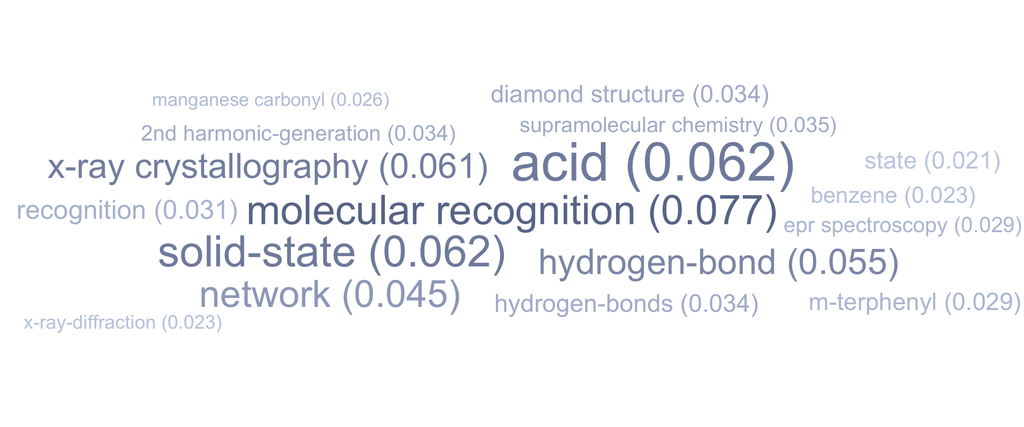

This community in Cluster 7 examines how molecules recognize one another and assemble in the solid state. “Molecular recognition” (0.077), “solid-state” (0.062), and “hydrogen-bond” (0.055) point to questions about how molecules associate and how those associations extend into networks within a solid. “X-ray crystallography” (0.061) points to a method for determining those arrangements. “Second-harmonic generation” adds a strand on the optical behaviour of solids.

The closest connection is to Community 2, which also uses diffraction to determine structure. Here, the emphasis is on the arrangement of molecules relative to one another and the hydrogen bonds that help hold them together. The adduct community offers another parallel through its interest in how chemical species associate. Its keywords emphasize formation and dissociation, while this community emphasizes the structures that molecular associations produce in solids.

## Community 12: Metal complexes as precursors for atomic layer deposition

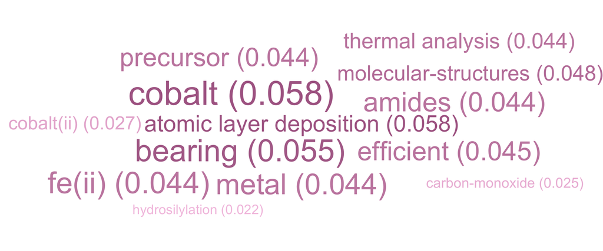

This community in Cluster 7 focuses on how metal compounds are prepared and evaluated for use in atomic layer deposition. “Atomic layer deposition” and “cobalt” share the highest within-community PageRank (0.058). “Amides,” “Fe(II),” and “Co(II)” give the work a more specific chemical focus, while “molecular-structures,” “precursor,” and “thermal analysis” point to how researchers characterize candidate compounds and assess their behaviour when heated. These properties help determine whether a compound can serve as a starting material for growing a thin film.

The focus on metal complexes connects this work to Community 1, and the use of molecular structure to characterize compounds connects it to Community 2. Here, those questions serve a materials application. Researchers are interested in how the structure and thermal behaviour of a compound affect its suitability for deposition. “Hydrosilylation” also points to work on catalytic reactivity within the same grouping.

## Community 13: Molecular structure and reaction pathways

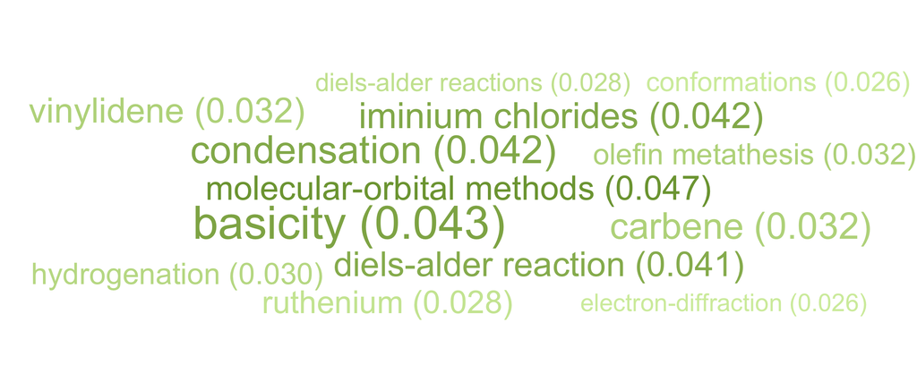

This community in Cluster 7 brings together research on molecular structure and how chemical reactions proceed. “Molecular-orbital methods” leads the within-community PageRank (0.047), followed by “basicity” (0.043), “condensation” and “iminium chlorides” (both 0.042), and “Diels–Alder reaction” (0.041). Molecular orbital calculations, conformations, and electron diffraction point to work on how molecules are arranged and how their electrons are distributed. Condensation and Diels–Alder reactions give the community a focus in organic transformations, while ruthenium, carbenes, olefin metathesis, and hydrogenation point to an organometallic strand.

The community overlaps with Community 2 in its use of calculations and diffraction to study structure, and with Community 1 in its attention to how compounds react. Its emphasis is on structure and reactivity in the context of specific transformations, from reactions that form rings to those that rearrange or reduce carbon–carbon double bonds.

## Community 14: Cholinesterases and Alzheimer’s disease

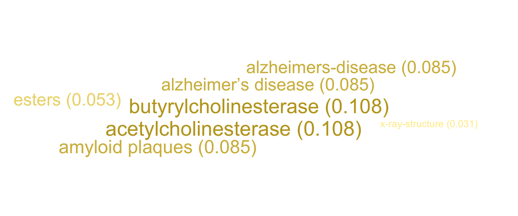

This community in Cluster 7 centres on cholinesterases in Alzheimer’s research. “Butyrylcholinesterase” and “acetylcholinesterase” share the highest within-community PageRank (0.108), followed by two variants of “Alzheimer’s disease” and “amyloid plaques” (all about 0.085). “Esters” points to the class of compounds these enzymes act on, while “X-ray structure” connects the community to Community 2’s work on determining molecular structure. The tuberculosis community provides another point of comparison. Both bring chemistry into biomedical research, with the tuberculosis community emphasizing compound discovery and this one emphasizing enzymes in the context of disease.

## Community 15: Main-group chemistry and redox-active ligands

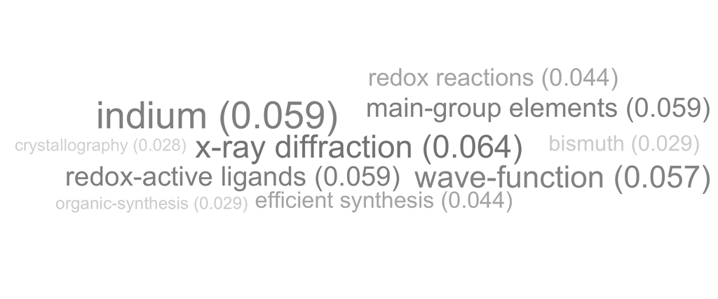

This community in Cluster 7 examines the structure and reactivity of main-group compounds. “X-ray diffraction” has the highest within-community PageRank (0.064), with “indium,” “redox-active ligands,” and “main-group elements” close behind (each 0.059). Diffraction and crystallography connect this community to Community 2’s work on determining molecular structure. “Redox-active ligands” and “redox reactions” give that structural work a question about reactivity: what role can the ligands themselves play in gaining or losing electrons? The terms “efficient synthesis” and “organic-synthesis” also point to an interest in using this chemistry to make compounds.

Like Community 1, this community brings structural characterization and reactivity together. Its distinguishing emphasis is on main-group elements such as indium and bismuth. It also shares an interest in ligands with the phosphorus and Lewis acidity community, where palladium cross-coupling provides a catalytic setting. Here, the ligand’s role in electron transfer is the focus.

## Community 16: Chemical exposure and toxicity

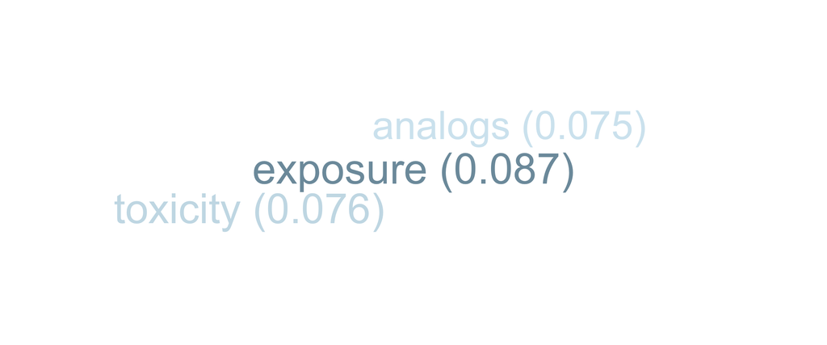

This community in Cluster 7 points to research on chemical exposure and toxicity. “Exposure” has the highest within-community PageRank (0.087), followed by “toxicity” (0.076) and “analogs” (0.075). “Analogs” suggests an interest in comparing structurally similar compounds, though the table leaves open which compounds or biological systems were studied. The connection to the tuberculosis and cholinesterase communities is their shared interest in what compounds do in biological settings. Those communities have named biomedical contexts, while the emphasis here is on the potential for harm following exposure.

## Most cited publications by community

Select one of the communities above to populate the table. The table shows up to five publications per selected research community, arranged by highest Total Citation count within the research community under consideration. Under Membership vector the column headers indicate abbreviated research community labels. Each row sum totals 1.0. Values of 1 indicate maximal research community affiliation; distributed values indicate multithematic papers whose affiliation reaches into more than one research community (Aria et al. 2026; Aria and Cuccurullo 2026). TCpY = Total Citations per Year.

Community:

| Publication title | Year | TC | TCpY | Membership vector Str. | Membership vector Cry. | Membership vector Ren. | Membership vector Ant. | Membership vector Add. | Membership vector Pho. | Membership vector Tra1. | Membership vector Tra2. | Membership vector Ion. | Membership vector Ami. | Membership vector Mol1. | Membership vector Met. | Membership vector Mol2. | Membership vector Cho. | Membership vector Mai. | Membership vector Che. |
| --- | --- | --- | --- | --- | --- | --- | --- | --- | --- | --- | --- | --- | --- | --- | --- | --- | --- | --- | --- |
| Use of Alkane Elimination in the One-Step Synthesis of Organoscandium Complexes Containing a New Multidentate Cyclopentadienyl Ligand | 1996 | 116 | 3.7 | 0.8 | 0.2 | 0.0 | 0.0 | 0.0 | 0.0 | 0.0 | 0.0 | 0.0 | 0.0 | 0.0 | 0.0 | 0.0 | 0.0 | 0.0 | 0.0 |
| New Ligand Environments for Soluble Ziegler-Natta Olefin Polymerization Catalyst Precursors - x-Ray Structures of [(Eta(5)-c(5)Me(4)Si(Me(2))Och2c4h7nh)Zrcl3] and [(Eta(5)-c(5)Me(4)Sime(3))(2)Zr-2(Ch3… | 1995 | 59 | 1.8 | 1.0 | 0.0 | 0.0 | 0.0 | 0.0 | 0.0 | 0.0 | 0.0 | 0.0 | 0.0 | 0.0 | 0.0 | 0.0 | 0.0 | 0.0 | 0.0 |
| Attachment of c(5)Me(4)Hsi(Me(2))Nh-t-C4h9 to Yttrium via Amine Elimination. x-Ray Structure of [(Eta(5)-c(5)Me(4))Si(Me(2))-Eta(1)-n-t-C4h9]yn(Sime(3))(2) | 1995 | 56 | 1.8 | 1.0 | 0.0 | 0.0 | 0.0 | 0.0 | 0.0 | 0.0 | 0.0 | 0.0 | 0.0 | 0.0 | 0.0 | 0.0 | 0.0 | 0.0 | 0.0 |
| Anhydrous Tempo-H: Reactions of a Good Hydrogen Atom Donor with Low-Valent Carbon Centres | 2011 | 45 | 2.8 | 0.7 | 0.0 | 0.0 | 0.0 | 0.0 | 0.0 | 0.0 | 0.0 | 0.2 | 0.2 | 0.0 | 0.0 | 0.0 | 0.0 | 0.0 | 0.0 |
| Rational Synthesis and Mutual Conversion of Bis-n-Heterocyclic Diphosphanes and Secondary n-Heterocyclic Phosphanes | 2013 | 43 | 3.1 | 0.9 | 0.0 | 0.0 | 0.0 | 0.0 | 0.0 | 0.0 | 0.0 | 0.0 | 0.0 | 0.0 | 0.1 | 0.0 | 0.0 | 0.0 | 0.0 |
| Porous Solids by Design - [zn(4,4'-Bpy)(2)(Sif6)](n)Center-Dot-Xdmf, a Single Framework Octahedral Coordination Polymer with Large Square Channels | 1995 | 717 | 22.4 | 0.0 | 1.0 | 0.0 | 0.0 | 0.0 | 0.0 | 0.0 | 0.0 | 0.0 | 0.0 | 0.0 | 0.0 | 0.0 | 0.0 | 0.0 | 0.0 |
| Controlled Design of Oligomeric Ethers with Pendant Cyclopentadienyliron Moieties | 1995 | 41 | 1.3 | 0.3 | 0.7 | 0.0 | 0.0 | 0.0 | 0.0 | 0.0 | 0.0 | 0.0 | 0.0 | 0.0 | 0.0 | 0.0 | 0.0 | 0.0 | 0.0 |
| Cobalt Cage Complexes with N3s3 Donor Sets and Differing Cavity Sizes:: a Novel Macrobicyclic Cage with a Contracted Cap | 1999 | 25 | 0.9 | 0.0 | 1.0 | 0.0 | 0.0 | 0.0 | 0.0 | 0.0 | 0.0 | 0.0 | 0.0 | 0.0 | 0.0 | 0.0 | 0.0 | 0.0 | 0.0 |
| Compounds with Unbridged Dative Metal-Metal Bonds of Formula (R3p)2(Oc)3osw(Co)5 and Related Complexes | 2000 | 18 | 0.7 | 0.0 | 1.0 | 0.0 | 0.0 | 0.0 | 0.0 | 0.0 | 0.0 | 0.0 | 0.0 | 0.0 | 0.0 | 0.0 | 0.0 | 0.0 | 0.0 |
| An Ab Initio Study of Conformations and Sigmatropic Shifts in Triazene and Its Mono-, Di-, and Trimethyl Derivatives | 2002 | 16 | 0.6 | 0.0 | 1.0 | 0.0 | 0.0 | 0.0 | 0.0 | 0.0 | 0.0 | 0.0 | 0.0 | 0.0 | 0.0 | 0.0 | 0.0 | 0.0 | 0.0 |
| Energy Management and Control System for Laboratory Scale Microgrid Based Wind-Pv-Battery | 2017 | 321 | 32.1 | 0.0 | 0.0 | 1.0 | 0.0 | 0.0 | 0.0 | 0.0 | 0.0 | 0.0 | 0.0 | 0.0 | 0.0 | 0.0 | 0.0 | 0.0 | 0.0 |
| Effect of Soil Type and Moisture Content on Ground Heat Pump Performance | 1998 | 107 | 3.7 | 0.0 | 0.0 | 1.0 | 0.0 | 0.0 | 0.0 | 0.0 | 0.0 | 0.0 | 0.0 | 0.0 | 0.0 | 0.0 | 0.0 | 0.0 | 0.0 |
| Grid-Tied and Stand-Alone Hybrid Solar Power System for Desalination Plant | 2018 | 95 | 10.6 | 0.0 | 0.0 | 1.0 | 0.0 | 0.0 | 0.0 | 0.0 | 0.0 | 0.0 | 0.0 | 0.0 | 0.0 | 0.0 | 0.0 | 0.0 | 0.0 |
| Robust Feedback Linearizing Control with Sliding Mode Compensation for a Grid-Connected Photovoltaic Inverter System under Unbalanced Grid Voltages | 2017 | 71 | 7.1 | 0.0 | 0.0 | 1.0 | 0.0 | 0.0 | 0.0 | 0.0 | 0.0 | 0.0 | 0.0 | 0.0 | 0.0 | 0.0 | 0.0 | 0.0 | 0.0 |
| a Survey of Video Game Preferences in Adults: Building Better Games for Older Adults | 2017 | 53 | 5.3 | 0.0 | 0.0 | 1.0 | 0.0 | 0.0 | 0.0 | 0.0 | 0.0 | 0.0 | 0.0 | 0.0 | 0.0 | 0.0 | 0.0 | 0.0 | 0.0 |
| Antimicrobial and Antimycobacterial Activities of Aliphatic Amines Derived from Vanillin | 2015 | 16 | 1.3 | 0.0 | 0.1 | 0.0 | 0.8 | 0.0 | 0.0 | 0.0 | 0.0 | 0.0 | 0.0 | 0.0 | 0.1 | 0.0 | 0.0 | 0.0 | 0.0 |
| Anti-Mycobacterial Activities of Copper(Ii) Complexes. Part Ii. Lipophilic Hydroxypyridinones Derived from Maltol | 2015 | 10 | 0.8 | 0.1 | 0.0 | 0.1 | 0.8 | 0.0 | 0.0 | 0.0 | 0.0 | 0.0 | 0.0 | 0.0 | 0.0 | 0.0 | 0.0 | 0.0 | 0.0 |
| Amino-Acid Derived Benzazaboroles: Structure and Function of a New Chemotype | 2025 | 2 | 1.0 | 0.4 | 0.0 | 0.0 | 0.6 | 0.0 | 0.0 | 0.0 | 0.0 | 0.0 | 0.0 | 0.0 | 0.0 | 0.0 | 0.0 | 0.0 | 0.0 |
| (Η5-Cyclopentadienyl)(Η6-1,2-Dipyrrolidin-1-Ylbenz Ene)Iron(Ii) Hexafluoridophosphate | 2009 | 2 | 0.1 | 0.5 | 0.0 | 0.0 | 0.5 | 0.0 | 0.0 | 0.0 | 0.0 | 0.0 | 0.0 | 0.0 | 0.0 | 0.0 | 0.0 | 0.0 | 0.0 |
| a Simple Complex on the Verge of Breakdown: Isolation of the Elusive Cyanoformate Ion | 2014 | 45 | 3.5 | 0.0 | 0.5 | 0.0 | 0.0 | 0.5 | 0.0 | 0.0 | 0.0 | 0.0 | 0.0 | 0.0 | 0.0 | 0.0 | 0.0 | 0.0 | 0.0 |
| Trans Alkenylpyridine and Alkenylamine Complexes of Platinum | 2000 | 28 | 1.0 | 0.2 | 0.1 | 0.0 | 0.1 | 0.5 | 0.0 | 0.0 | 0.0 | 0.0 | 0.0 | 0.0 | 0.0 | 0.0 | 0.0 | 0.0 | 0.0 |
| x-Ray Crystal Structure of Trans-Dinitratotetrapyridinezinc(Ii)-Pyridine Solvate, a Clathrate Compound | 1996 | 10 | 0.3 | 0.4 | 0.0 | 0.0 | 0.0 | 0.6 | 0.0 | 0.0 | 0.0 | 0.0 | 0.0 | 0.0 | 0.0 | 0.0 | 0.0 | 0.0 | 0.0 |
| Application of an Air Stable Pd Oxazoline Complex for Heck, Suzuki, Sonogashira and Related c-c Bond-Forming Reactions | 2004 | 80 | 3.5 | 0.1 | 0.1 | 0.0 | 0.0 | 0.0 | 0.7 | 0.0 | 0.0 | 0.0 | 0.1 | 0.0 | 0.0 | 0.0 | 0.0 | 0.0 | 0.0 |
| Lewis Base Stabilized Oxophosphonium Ions | 2012 | 21 | 1.4 | 0.3 | 0.0 | 0.0 | 0.0 | 0.0 | 0.7 | 0.0 | 0.0 | 0.0 | 0.0 | 0.0 | 0.0 | 0.0 | 0.0 | 0.0 | 0.0 |
| Synthesis, Characterization, and Application of Palladium Complexes Containing 8-Quinolylphosphinite Ligands | 2010 | 6 | 0.4 | 0.2 | 0.0 | 0.0 | 0.0 | 0.0 | 0.5 | 0.0 | 0.0 | 0.0 | 0.0 | 0.0 | 0.0 | 0.2 | 0.0 | 0.0 | 0.0 |
| Pnictogeniii Dications Supported by Bzimpy Ligands | 2025 | 4 | 2.0 | 0.1 | 0.0 | 0.0 | 0.0 | 0.0 | 0.9 | 0.0 | 0.0 | 0.0 | 0.0 | 0.0 | 0.0 | 0.0 | 0.0 | 0.0 | 0.0 |
| Air-Stable Pnictogeniii Dications Supported by Terpyridine | 2025 | 3 | 1.5 | 0.1 | 0.0 | 0.0 | 0.0 | 0.0 | 0.9 | 0.0 | 0.0 | 0.0 | 0.0 | 0.0 | 0.0 | 0.0 | 0.0 | 0.0 | 0.0 |
| Optimal Decisions in a Retailer Stackelberg Supply Chain | 2017 | 64 | 6.4 | 0.0 | 0.0 | 0.5 | 0.0 | 0.0 | 0.0 | 0.5 | 0.0 | 0.0 | 0.0 | 0.0 | 0.0 | 0.0 | 0.0 | 0.0 | 0.0 |
| Oxidation of Meso-Tetraphenyl-2,3-Dihydroxychlorin: Simplified Synthesis of Β,β′-Dioxochlorins | 2003 | 55 | 2.3 | 0.4 | 0.0 | 0.0 | 0.0 | 0.0 | 0.0 | 0.6 | 0.0 | 0.0 | 0.0 | 0.0 | 0.0 | 0.0 | 0.0 | 0.0 | 0.0 |
| The 1st Stable Zirconium Alkylidene Complex Formed via Alpha-Hydrogen Abstraction - Synthesis and x-Ray Crystal-Structure of [eta-5-C5h3-1,3-(Sime2ch2ppr(i)2)2]zr=chph(Cl) | 1993 | 112 | 3.3 | 0.2 | 0.0 | 0.0 | 0.0 | 0.0 | 0.0 | 0.0 | 0.8 | 0.0 | 0.0 | 0.0 | 0.0 | 0.0 | 0.0 | 0.0 | 0.0 |
| Mechanistic Studies of the Formation of Zirconium Alkylidene Complexes [η5-C5h3-1,3-(Sime2ch2< /Sub>ppri2)2]zr=chr(Cl) (r = Ph, Sime3) | 1999 | 51 | 1.8 | 0.3 | 0.0 | 0.0 | 0.0 | 0.0 | 0.0 | 0.0 | 0.7 | 0.0 | 0.0 | 0.0 | 0.0 | 0.0 | 0.0 | 0.0 | 0.0 |
| Synthesis, Structure and Reactivity of Mononuclear Paramagnetic Complexes of Zirconium and Hafnium | 1996 | 16 | 0.5 | 0.2 | 0.2 | 0.0 | 0.0 | 0.0 | 0.0 | 0.0 | 0.6 | 0.0 | 0.0 | 0.0 | 0.0 | 0.0 | 0.0 | 0.0 | 0.0 |
| Synthesis of Chromium(Iii) Bis(Benzamidinate) Complexes via Single Electron Oxidation | 2007 | 5 | 0.2 | 0.0 | 0.2 | 0.0 | 0.0 | 0.0 | 0.0 | 0.0 | 0.8 | 0.0 | 0.0 | 0.0 | 0.0 | 0.0 | 0.0 | 0.0 | 0.0 |
| The Coordination Chemistry of O,o'-i-Pr2c6h3-Bis(Imino) Acenaphthene to Group 13 Trihalides | 2002 | 36 | 1.4 | 0.4 | 0.0 | 0.0 | 0.0 | 0.0 | 0.0 | 0.0 | 0.0 | 0.6 | 0.0 | 0.0 | 0.0 | 0.0 | 0.0 | 0.0 | 0.0 |
| Grignard Reactions in Pyridinium and Phosphonium Ionic Liquids | 2011 | 30 | 1.9 | 0.3 | 0.0 | 0.1 | 0.0 | 0.0 | 0.0 | 0.0 | 0.0 | 0.6 | 0.0 | 0.0 | 0.0 | 0.0 | 0.0 | 0.0 | 0.0 |
| Manifestations of Noncovalent Interactions in the Solid-State .3. x-Ray Crystal-Structures of [h4(Cyclam)][fecl5(Oh2)](Cl)2 and [h4(Cyclam)][cf3coo]4, 2 Network Hydrogen-Bonded Solids | 1993 | 24 | 0.7 | 0.1 | 0.1 | 0.0 | 0.0 | 0.0 | 0.0 | 0.0 | 0.0 | 0.8 | 0.0 | 0.0 | 0.0 | 0.0 | 0.0 | 0.0 | 0.0 |
| Air Stable Liquid Clathrates - Solid-State Structure and Hydrocarbon Solubility of Organic Cation Triiodide Salts | 1991 | 17 | 0.5 | 0.0 | 0.1 | 0.0 | 0.0 | 0.0 | 0.0 | 0.0 | 0.0 | 0.9 | 0.0 | 0.0 | 0.0 | 0.0 | 0.0 | 0.0 | 0.0 |
| The Crystal Structures of Two Isomers of 5-(Phenylisothiazolyl)-1,3,4-Oxathiazol-2-One | 2017 | 2 | 0.2 | 0.1 | 0.2 | 0.2 | 0.0 | 0.0 | 0.0 | 0.0 | 0.0 | 0.5 | 0.0 | 0.0 | 0.0 | 0.0 | 0.0 | 0.0 | 0.0 |
| Mapping Dual-Base-Enabled Nickel-Catalyzed Aryl Amidations: Application in the Synthesis of 4-Quinolones | 2022 | 32 | 6.4 | 0.1 | 0.0 | 0.0 | 0.0 | 0.0 | 0.0 | 0.0 | 0.0 | 0.0 | 0.9 | 0.0 | 0.0 | 0.0 | 0.0 | 0.0 | 0.0 |
| Ionic Liquids and Acid Gas Capture: Water and Oxygen as Confounding Factors | 2012 | 18 | 1.2 | 0.0 | 0.4 | 0.0 | 0.0 | 0.0 | 0.0 | 0.0 | 0.0 | 0.0 | 0.6 | 0.0 | 0.0 | 0.0 | 0.0 | 0.0 | 0.0 |
| Synthesis of Dihydroquinoxaline-2(1h)-Ones via Palladium-Catalyzed Intramolecular c-n Bond Formation | 2016 | 8 | 0.7 | 0.2 | 0.0 | 0.0 | 0.0 | 0.0 | 0.0 | 0.0 | 0.0 | 0.0 | 0.6 | 0.0 | 0.2 | 0.0 | 0.0 | 0.0 | 0.0 |
| Nickel-Catalyzed n-Arylation of Sulfinamides: a Comparative Study Versus Analogous Sulfonamide Cross-Couplings | 2022 | 7 | 1.4 | 0.3 | 0.0 | 0.0 | 0.0 | 0.0 | 0.0 | 0.0 | 0.0 | 0.0 | 0.7 | 0.0 | 0.0 | 0.0 | 0.0 | 0.0 | 0.0 |
| The First Example of Trimethylsilyl Methylenenitronate Reacting with Aldehydes under an Apparent Mukaiyama Nitro-Aldol Reaction | 2011 | 6 | 0.4 | 0.1 | 0.0 | 0.0 | 0.0 | 0.0 | 0.0 | 0.0 | 0.0 | 0.0 | 0.7 | 0.0 | 0.0 | 0.0 | 0.0 | 0.2 | 0.0 |
| Supramolecular Chemistry of [mn(Co)3(Mu-3-Oh)]4 - Assembly of a Cubic Hydrogen-Bonded Diamondoid Network with 1,2-Diaminoethane | 1992 | 146 | 4.2 | 0.2 | 0.0 | 0.2 | 0.0 | 0.0 | 0.0 | 0.0 | 0.0 | 0.0 | 0.0 | 0.6 | 0.0 | 0.0 | 0.0 | 0.0 | 0.0 |
| Formation of Interwoven 2-d Networks by the Spontaneous Strict Self-Assembly of [(m(Co)3(Mu(3)-Oh))4](M=mn, Re) and Complementary Angular Spacer Molecules | 1993 | 69 | 2.0 | 0.1 | 0.0 | 0.0 | 0.0 | 0.0 | 0.0 | 0.0 | 0.0 | 0.0 | 0.0 | 0.9 | 0.0 | 0.0 | 0.0 | 0.0 | 0.0 |
| Supramolecular Chemistry of [(m(Co)(3)(Mu(3)-Oh))4] (M=mn or Re) - a Modular Approach to Crystal Engineering of Superdiamondoid Networks | 1995 | 65 | 2.0 | 0.0 | 0.0 | 0.1 | 0.0 | 0.0 | 0.0 | 0.0 | 0.0 | 0.0 | 0.0 | 0.9 | 0.0 | 0.0 | 0.0 | 0.0 | 0.0 |
| Synthesis of the Bulky m-Terphenyl Phenol Ar*oh (Ar* =c6h3-2,6-Mes2, Mes=2,4,6-Trimethylphenyl) and the Preparation and Structural Characterization of Several of Its Metal Complexes | 2008 | 56 | 2.9 | 0.3 | 0.1 | 0.0 | 0.0 | 0.0 | 0.0 | 0.0 | 0.0 | 0.0 | 0.0 | 0.6 | 0.0 | 0.0 | 0.0 | 0.0 | 0.0 |
| Supramolecular Chemistry of [m(Co)3(Mu-3-Oh)]4 (m = Mn, Re) -Spontaneous Strict Self-Assembly of Distorted Super-Diamondoid Networks that are Capable of Enclathrating Acetonitrile | 1993 | 54 | 1.6 | 0.0 | 0.0 | 0.2 | 0.0 | 0.0 | 0.0 | 0.0 | 0.0 | 0.0 | 0.0 | 0.8 | 0.0 | 0.0 | 0.0 | 0.0 | 0.0 |
| Co(Ii) Amide, Pyrrolate, and Aminopyridinate Complexes: Assessment of their Manifold Structural Chemistry and Thermal Properties** | 2021 | 7 | 1.2 | 0.0 | 0.1 | 0.0 | 0.0 | 0.0 | 0.0 | 0.0 | 0.0 | 0.0 | 0.0 | 0.0 | 0.9 | 0.0 | 0.0 | 0.0 | 0.0 |
| An Unusual Tri-Coordinate Co(Ii) Silylamide with Potential for Chemical Vapor Deposition Processes | 2022 | 3 | 0.6 | 0.1 | 0.0 | 0.0 | 0.0 | 0.0 | 0.0 | 0.0 | 0.0 | 0.0 | 0.0 | 0.0 | 0.9 | 0.0 | 0.0 | 0.0 | 0.0 |
| Biodegradable Ionic Liquids: Selected Synthetic Applications | 2007 | 40 | 2.0 | 0.2 | 0.0 | 0.3 | 0.0 | 0.0 | 0.0 | 0.0 | 0.0 | 0.0 | 0.0 | 0.0 | 0.0 | 0.5 | 0.0 | 0.0 | 0.0 |
| Ruthenium Vinylidene and Carbyne Complexes Containing a Multifunctional Tridentate Ligand with a Pnn Donor Set | 2006 | 17 | 0.8 | 0.1 | 0.0 | 0.0 | 0.0 | 0.0 | 0.0 | 0.0 | 0.0 | 0.0 | 0.0 | 0.0 | 0.0 | 0.9 | 0.0 | 0.0 | 0.0 |
| Reactivity of 1,3-Dichloro-1,3-Bis(Dimethylamino)-Propenium Salts with Primary Amines | 2021 | 4 | 0.7 | 0.0 | 0.2 | 0.0 | 0.0 | 0.0 | 0.0 | 0.0 | 0.0 | 0.0 | 0.0 | 0.0 | 0.0 | 0.8 | 0.0 | 0.0 | 0.0 |
| An Ab Initio Study of 5,6-Disubstituted 1,3-Cyclohexadienes | 2009 | 4 | 0.2 | 0.1 | 0.1 | 0.0 | 0.0 | 0.0 | 0.0 | 0.0 | 0.0 | 0.0 | 0.0 | 0.0 | 0.0 | 0.8 | 0.0 | 0.0 | 0.0 |
| 1-(3-Tert-Butylphenyl)-2,2,2-Trifluoroethanone as a Potent Transition-State Analogue Slow-Binding Inhibitor of Human Acetylcholinesterase: Kinetic, Md and Qm/Mm Studies | 2020 | 9 | 1.3 | 0.0 | 0.1 | 0.0 | 0.0 | 0.2 | 0.0 | 0.0 | 0.0 | 0.2 | 0.0 | 0.0 | 0.0 | 0.0 | 0.5 | 0.0 | 0.0 |
| Synthesis and Preliminary Evaluation of Piperidinyl and Pyrrolidinyl Iodobenzoates as Imaging Agents for Butyrylcholinesterase | 2011 | 8 | 0.5 | 0.1 | 0.0 | 0.0 | 0.0 | 0.0 | 0.0 | 0.0 | 0.0 | 0.0 | 0.0 | 0.0 | 0.0 | 0.0 | 0.9 | 0.0 | 0.0 |
| Thioesters for the in Vitro Evaluation of Agents to Image Brain Cholinesterases | 2013 | 3 | 0.2 | 0.2 | 0.1 | 0.0 | 0.0 | 0.0 | 0.0 | 0.0 | 0.0 | 0.0 | 0.0 | 0.0 | 0.0 | 0.0 | 0.7 | 0.0 | 0.0 |
| Quantum Crystallography: Current Developments and Future Perspectives | 2018 | 150 | 16.7 | 0.0 | 0.2 | 0.0 | 0.0 | 0.0 | 0.0 | 0.0 | 0.0 | 0.0 | 0.0 | 0.3 | 0.0 | 0.0 | 0.0 | 0.5 | 0.0 |
| Two Projector Triple Products in Quantum Crystallography | 2022 | 8 | 1.6 | 0.3 | 0.0 | 0.0 | 0.0 | 0.0 | 0.0 | 0.0 | 0.0 | 0.0 | 0.0 | 0.0 | 0.0 | 0.0 | 0.0 | 0.7 | 0.0 |
| Synthesis, Structure and Reactivity of Organoindium 1,2-Benzenedithiolates and 2-Amidobenzenethiolates | 2023 | 3 | 0.8 | 0.2 | 0.1 | 0.0 | 0.0 | 0.0 | 0.0 | 0.0 | 0.0 | 0.0 | 0.0 | 0.0 | 0.0 | 0.0 | 0.0 | 0.7 | 0.0 |
| (Η5-Cyclopentadienyl)[(1,2,3,4,4a,10a-η)-1-Methylthianthrene] Iron(Ii) Hexafluoridophosphate Acetone 0.33-Solvate | 2009 | 1 | 0.1 | 0.2 | 0.0 | 0.0 | 0.2 | 0.0 | 0.0 | 0.0 | 0.0 | 0.0 | 0.0 | 0.0 | 0.0 | 0.0 | 0.0 | 0.6 | 0.0 |
| Synthesis, Electrochemistry, and Reactivity of Bismuth(Iii) and Indium(Iii) Dithiolene Complexes | 2025 | 0 | 0.0 | 0.1 | 0.2 | 0.0 | 0.0 | 0.0 | 0.0 | 0.0 | 0.0 | 0.0 | 0.0 | 0.0 | 0.0 | 0.0 | 0.0 | 0.7 | 0.0 |
| a Remote Sensing Based Study of Tropospheric Ozone Concentration Amid Covid-19 Lockdown over India using Sentinel-5p Satellite Data | 2022 | 13 | 2.6 | 0.2 | 0.0 | 0.0 | 0.0 | 0.0 | 0.0 | 0.0 | 0.0 | 0.0 | 0.0 | 0.0 | 0.0 | 0.0 | 0.0 | 0.0 | 0.8 |
| Harnessing the Resolution Power of Two-Dimensional Liquid Chromatography (2d-Lc) for the Screening of Bisphenol Contaminants in Canned Food Items | 2024 | 4 | 1.3 | 0.3 | 0.0 | 0.0 | 0.0 | 0.0 | 0.0 | 0.0 | 0.0 | 0.0 | 0.0 | 0.0 | 0.0 | 0.0 | 0.0 | 0.0 | 0.7 |

## References

Aria, Massimo, and Corrado Cuccurullo. 2026. *Science Mapping Analysis: A Primer with Biblioshiny*. Mailand: McGraw-Hill Education.

Aria, Massimo, Luca D’Aniello, Michelangelo Misuraca, and Maria Spano. 2026. “Rethinking Thematic Evolution in Science Mapping:an Integrated Framework for Longitudinal Analysis.” *Journal of Informetrics* 20 (4): 101877. https://doi.org/10.1016/j.joi.2026.101877.